# CNEOS Close Approach Data Exploration

Cory Cone

2/23/2020

# 1 Introduction

The Center for Near-Earth Object Studies (CNEOS) is a division of NASA computing asteroid and comet orbits and their odds of Earth Impact. (source: https://cneos.jpl.nasa.gov/)

For this analysis, I used a dataset queried from the NEO database that include all NEOs matching a certain criteria (described below) as well as a second dataset of those that have any probability (past, present, future) of hitting Earth.

I wanted to analyze these not only because the subject matter is exciting, but because this particular data is very new to me, and I wanted to see how I did with data and values that were unfamiliar to those I’d worked with in the past (for instance, Lunar Distance and NEO Diameter). I also thought these particular datasets posed some tidying challenges that would be fun to solve, which we’ll explore next.

## 1.1 Data Dictionary

A lot of the terminology used here was new to me. I am including here the Data Dictionary for all fields and columns we’ll be using in our analysis for reference. This can be found on https://cneos.jpl.nasa.gov/ca/ and https://cneos.jpl.nasa.gov/sentry/ by expanding *Table Column Descriptions*.

**NEO Earth Close Approaches**

- Object: Designation of NEO (Name)
- Close-Approach (CA) Date: Date and time (TDB) of closest Earth approach.
- CA Distance Nominal (LD | au): The most likely (Nominal) close-approach distance (Earth center to NEO center), in LD (Lunar Distance) and au.
- V relative (km/s): Object velocity relative to Earth at close-approach.
- Estimated Diameter: Diameter range (min - max) estimated from the asteroid’s absolute magnitude (H) and limiting albedos of 0.25 and 0.05.
- au: One Astronomical Unit (au) is approximately 150 million kilometers
- LD: One Lunar Distance (LD) is approximately 384,000 kilometers

**Sentry Earth Impact Monitoring**

- Year Range: Time span over which impacts have been detected
- Potential Impacts: Number of dynamically distinct potential impacts that have been detected by Sentry
- Impact Probability (cumulative): Sum of the impact probabilities from all detected potential impacts.
- Palermo Scale (cum.): Cumulative hazard rating according to the Palermo technical impact hazard scale, based on the tabulated impact date, impact probability and impact energy.
- Palermo Scale (max.): Maximum hazard rating according to the Palermo technical impact hazard scale, based on the tabulated impact date, impact probability and impact energy.
- Torino Scale (max.): Maximum detected hazard rating according to the Torino impact hazard scale, based on the tabulated impact probability and impact energy. The Torino scale is defined only for potential impacts less than 100 years in the future.

# 2 Required packages

The required packages will be:

- tidyverse, for data wrangling, cleaning, and plotting
- lubridate, for date manipulation
- stringr, for data wrangling and cleaning
- data.table, for data wrangling and cleaning

```r
library(tidyverse)
library(lubridate)
library(stringr)
library(data.table)
```

# 3 Data Prep

## 3.1 Download the NEO Datasets

The datasets I used were downloaded on 2/18/2020.

**NEO Close Approach Data** from: https://cneos.jpl.nasa.gov/ca/

Table Filters:

- All Available Data
- Nominal Dist. <=0.05au
- no H limit

**Sentry Earth Impact Monitoring** from https://cneos.jpl.nasa.gov/sentry/

Table Filters:

- Observed Anytime
- Any Impact Probability
- Any Palermo scale
- Any H

## 3.2 Import

Once downloaded, we can place them into a datafiles folder within out working directory and import into R.

```r
cneos_closeapproach_data <- read.csv("datafiles/cneos_closeapproach_data.csv", stringsAsFactors = FALSE)
cneos_sentry_summary_data <- read.csv("datafiles/cneos_sentry_summary_data.csv", stringsAsFactors = FALSE)
```

```r
knitr::kable(
  cneos_closeapproach_data[1:5,],
  caption = "First 5 Rows of All NEO Close Approach Data"
)
```

First 5 Rows of All NEO Close Approach Data

| Object | Close.Approach..CA..Date | CA.Distance.Nominal..LD…au. | CA.Distance.Minimum..LD…au. | V.relative..km.s. | V.infinity..km.s. | H..mag. | Estimated.Diameter | X |
| --- | --- | --- | --- | --- | --- | --- | --- | --- |
| 170903 (2004 WS2) | 1900-Jan-01 00:11Â ±Â Â Â Â 01:00 | 35.87 \| 0.09218 | 35.49 \| 0.09120 | 16.75 | 16.75 | 18.1 | 640 m - 1.4 km | a0170903 |
| (2006 XO4) | 1900-Jan-01 03:13Â ±Â Â Â Â 00:23 | 44.48 \| 0.11429 | 44.47 \| 0.11427 | 7.40 | 7.39 | 23.4 | 56 m - 120 m | bK06X04O |
| (2013 WU45) | 1900-Jan-01 22:29Â ±Â Â Â Â 00:01 | 65.98 \| 0.16955 | 65.98 \| 0.16954 | 13.71 | 13.71 | 20.4 | 220 m - 490 m | bK13W45U |
| 313552 (2003 BX33) | 1900-Jan-02 03:07Â ±Â Â Â Â 00:03 | 53.04 \| 0.13629 | 53.03 \| 0.13626 | 15.95 | 15.95 | 20.9 | 180 m - 390 m | a0313552 |
| 417217 (2005 YS) | 1900-Jan-03 02:43Â ±Â < 00:01 | 40.00 \| 0.10278 | 40.00 \| 0.10278 | 19.14 | 19.14 | 19.6 | 320 m - 710 m | a0417217 |

```r
knitr::kable(
  cneos_sentry_summary_data[1:5,],
  caption = "First 5 Rows of Sentry Monitoring System Data"
)
```

First 5 Rows of Sentry Monitoring System Data

| Object.Designation.. | Year.Range.. | Potential.Impacts.. | Impact.Probability..cumulative. | Vinfinity..km.s. | H..mag. | Estimated.Diameter..km. | Palermo.Scale..cum.. | Palermo.Scale..max.. | Torino.Scale..max.. | X |
| --- | --- | --- | --- | --- | --- | --- | --- | --- | --- | --- |
| 29075 (1950 DA) | 2880-2880 | 1 | 1.2e-04 | 14.10 | 17.6 | 1.300 | -1.42 | -1.42 | NA | a0029075 |
| 101955 Bennu (1999 RQ36) | 2175-2199 | 78 | 3.7e-04 | 5.99 | 20.2 | 0.490 | -1.71 | -2.32 | NA | a0101955 |
| (1979 XB) | 2056-2113 | 2 | 7.0e-07 | 23.92 | 18.5 | 0.662 | -2.82 | -3.12 | 0 | bJ79X00B |
| 99942 Apophis (2004 MN4) | 2060-2105 | 12 | 8.9e-06 | 5.85 | 19.1 | 0.370 | -2.83 | -2.93 | 0 | a0099942 |
| (2000 SG344) | 2069-2113 | 101 | 2.6e-03 | 1.36 | 24.8 | 0.037 | -2.86 | -3.23 | 0 | bK00SY4G |

## 3.3 Clean & Prep

There is a lot of prep to do here, and then possibly some follow-up prep as we go along.

### 3.3.1 Clean column names

```r
colnames(cneos_closeapproach_data) <- c("Object", "Close-Approach_Date", "CA_Distance_Nominal",
                                        "CA_Distance_Minimum", "V_Relative", "V_Infinity", "H", "Est._Diameter", "UniqueID")

colnames(cneos_sentry_summary_data) <- c("Object", "Year_Range", "Potential_Impacts",
                                         "Cum_Impact_Probability", "V_Infinity", "H", "Est._Diameter",
                                         "Palermo_Scale_cum", "Palermo_Scale_max", "Torino_Scale", "UniqueID")
```

### 3.3.2 Format Close Approach Date

```r
cneos_closeapproach_data$`Close-Approach_Date` <-  substring(cneos_closeapproach_data$`Close-Approach_Date`,1,11)
```

### 3.3.3 Remove unneeded columns

```r
cneos_closeapproach_data  <- select(cneos_closeapproach_data,
                                    -V_Infinity,
                                    -H,
                                    -CA_Distance_Minimum)
cneos_sentry_summary_data <- select(cneos_sentry_summary_data,
                                    -Est._Diameter,
                                    -Object,
                                    -V_Infinity,
                                    -H)
```

### 3.3.4 Join the data

We can now join the two datasets. We’ll be doing a left outer and an inner join, so that we have the option to explore the entire set of NEOs (though this may not be used too much) as well as a subset of NEOs with a chance to strike Earth.

```r
collision_NEO <- inner_join(cneos_closeapproach_data,
                            cneos_sentry_summary_data,
                            by = "UniqueID")
all_NEO <- left_join(cneos_closeapproach_data,
                                cneos_sentry_summary_data,
                                by = "UniqueID")
```

### 3.3.5 Fix Object Name

One problem we can see is that the dataset includes parenthesis around the Object names. I’d like to remove that to make our lives a bit easier. For instance, the first object in the dataset looks like this: (2019 DS1)

```r
collision_NEO$Object <- gsub('[\\(\\)]', '', collision_NEO$Object)
```

Now, it looks better: 2019 DS1

### 3.3.6 Create Average Diameter Field

The last initial data prep step I’d like to take before digging in has to do with the Estimated Diameter column, which at the moment looks like this:

```r
knitr::kable(
  collision_NEO$Est._Diameter[1:5],
  caption = "First 5 Rows of Estimated Diameter"
)
```

First 5 Rows of Estimated Diameter

| x |
| --- |
| 20 m - 45 m |
| 3.8 m - 8.6 m |
| 5.3 m - 12 m |
| 8.0 m - 18 m |
| 5.3 m - 12 m |

This format is pretty useless to us. I’d like to get those **min** and **max** values into their own columns, and then also create an **average diameter** column for each object that we can use.

#### 3.3.6.1 Minimum Diameter Range

We’ll start by isolating the minimum value into its own column.

```r
collision_NEO$diam_min <- str_split_fixed(collision_NEO$Est._Diameter, "-", 2)[1:nrow(collision_NEO)]
```

The data includes measurements of meters and kilometers. We’ll clean up the the meters first. I run the first line 3 times because it removes one space at a time, and I wanted to make sure it got all of them. I expect there is a better way to do this, but it got the job done. The second part removes the m from the string.

```r
collision_NEO$diam_min <- str_remove(collision_NEO[collision_NEO$diam_min %like% 'm',]$diam_min, "[ ]")
collision_NEO$diam_min <- str_remove(collision_NEO[collision_NEO$diam_min %like% 'm',]$diam_min, "[ ]")
collision_NEO$diam_min <- str_remove(collision_NEO[collision_NEO$diam_min %like% 'm',]$diam_min, "[ ]")
collision_NEO$diam_min <- str_remove(collision_NEO$diam_min, "[m]")
```

Some of the values were so big they went into kilometer measurements. My solution here is not terribly clean, but there were so few that it worked for this data set.

fIRST, we find the k values.

```r
collision_NEO[collision_NEO$diam_min %like% 'k',]$diam_min
```

```
## [1] "1.0k" "1.0k" "1.0k" "1.0k" "1.0k" "1.0k" "1.0k" "1.0k"
```

Next, reassign them into their appropriate meter values, then finish off by making the column numeric.

```r
collision_NEO[collision_NEO$diam_min %like% 'k',]$diam_min <- c("1000","1000","1000","1000","1000","1000","1000","1000")
collision_NEO$diam_min <- as.numeric(collision_NEO$diam_min)
```

Repeat the entire process for the maximum range.

```r
collision_NEO$diam_max <- str_split_fixed(collision_NEO$Est._Diameter, "-", 2)[1:nrow(collision_NEO),2]
collision_NEO$diam_max <- str_remove(collision_NEO$diam_max, "[ ]")
collision_NEO$diam_max <- str_remove(collision_NEO$diam_max, "[ ]")
collision_NEO$diam_max <- str_remove(collision_NEO$diam_max, "[ ]")
collision_NEO$diam_max <- str_remove(collision_NEO$diam_max, "[m]")
collision_NEO[collision_NEO$diam_max %like% 'k',]$diam_max <- c("2300", "2300", "1100", "1000",
                                                                "2300", "1200", "2300", "2300",
                                                                "2300", "2300", "2300")
collision_NEO$diam_max <- as.numeric(collision_NEO$diam_max)
```

And finally, we can create a brand new column that has the **average diameter* of each NEO.

```r
collision_NEO$avg_diameter <- (collision_NEO$diam_min + collision_NEO$diam_max)/2
```

```r
knitr::kable(
  collision_NEO$avg_diameter[1:5],
  caption = "First 5 Rows of New Average Diameter Column"
)
```

First 5 Rows of New Average Diameter Column

| x |
| --- |
| 32.50 |
| 6.20 |
| 8.65 |
| 13.00 |
| 8.65 |

Goodbye, original column!

```r
collision_NEO <- select(collision_NEO, -Est._Diameter)
```

### 3.3.7 Polermo Scale Values

Finally, I’d like to translate the Polermo Scale into a new column representing the level of concern.

```r
collision_NEO$pscale[collision_NEO$Palermo_Scale_max < -2 ] <- "No Concern"
collision_NEO$pscale[collision_NEO$Palermo_Scale_max < 1 & collision_NEO$Palermo_Scale_max > -2] <- "Careful Monitoring"
collision_NEO$pscale[collision_NEO$Palermo_Scale_max > 0 ] <- "Some Concern"
```

# 4 The Data

Our working dataset, now called **collision_NEO** has 4840 rows and 15 columns.

Here is its structure.

```r
str(collision_NEO)
```

```
## 'data.frame':    4840 obs. of  15 variables:
##  $ Object                : chr  "2019 DS1" "2018 UL" "2010 UY7" "2016 SU2" ...
##  $ Close-Approach_Date   : chr  "1900-Feb-26" "1900-Jul-12" "1900-Oct-28" "1901-Jan-04" ...
##  $ CA_Distance_Nominal   : chr  "6.25 | 0.01605" "37.35 | 0.09597" "66.10 | 0.16984" "46.38 | 0.11918" ...
##  $ V_Relative            : num  10.8 8.31 9.19 9.97 12.18 ...
##  $ UniqueID              : chr  "bK19D01S" "bK18U00L" "bK10U07Y" "bK16S02U" ...
##  $ Year_Range            : chr  "2082-2108" "2097-2097" "2066-2114" "2102-2115" ...
##  $ Potential_Impacts     : int  5 1 46 12 1 16 8 16 1 4 ...
##  $ Cum_Impact_Probability: num  1.4e-03 3.6e-07 2.3e-04 4.4e-06 5.0e-10 2.7e-05 1.2e-08 3.2e-05 5.0e-10 1.0e-07 ...
##  $ Palermo_Scale_cum     : num  -3.29 -8.83 -5.75 -6.89 -11 -5.84 -6.94 -6.07 -11 -9.19 ...
##  $ Palermo_Scale_max     : num  -3.3 -8.83 -6.2 -7.27 -11 -6.15 -7.1 -6.12 -11 -9.28 ...
##  $ Torino_Scale          : int  0 0 0 0 0 0 0 0 0 0 ...
##  $ diam_min              : num  20 3.8 5.3 8 5.3 11 38 8 5.3 4.6 ...
##  $ diam_max              : num  45 8.6 12 18 12 25 86 18 12 10 ...
##  $ avg_diameter          : num  32.5 6.2 8.65 13 8.65 18 62 13 8.65 7.3 ...
##  $ pscale                : chr  "No Concern" "No Concern" "No Concern" "No Concern" ...
```

## 4.1 What percentage of known NEOs could strike Earth?

Of all known NEOs, past and future, how many of them are flagged by the Sentry Earth Monitoring System?

```r
all_objects <- data.frame(unique(all_NEO$Object))
all_prob_strike <- data.frame(unique(cneos_sentry_summary_data$UniqueID))
```

The unduplicated count of all objects is 17853, and the unduplicated count of all objects with a potential to strike earth is 986. That means **5.5228813%** of all NEOs in our data have a probability to strike Earth.

## 4.2 Of those objects that could strike Earth, how many close approaches occur each decade?

Because the data includes 299 years of NEO data, I’m going to look at it by decade.

```r
min(year(ymd(collision_NEO$`Close-Approach_Date`)))
```

```
## [1] 1900
```

```r
max(year(ymd(collision_NEO$`Close-Approach_Date`)))
```

```
## [1] 2199
```

```r
collision_NEO <- collision_NEO %>% mutate(decade = floor(year(ymd(collision_NEO$`Close-Approach_Date`))/10)*10)
```

Do any decades stand out from the crowd?

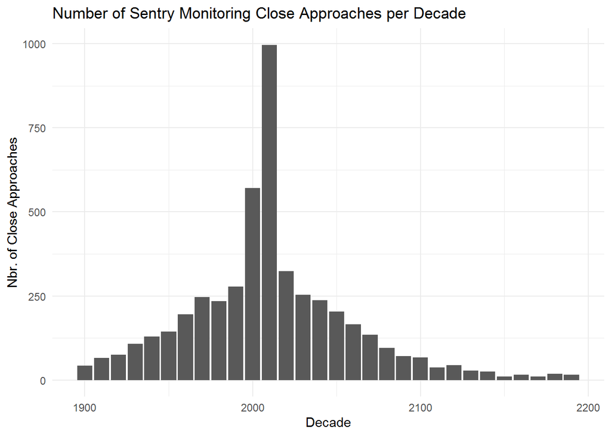

```r
ggplot(collision_NEO) + geom_bar(aes(x = decade)) +
  labs(title = "Number of Sentry Monitoring Close Approaches per Decade",
       x = "Decade",
       y = "Nbr. of Close Approaches") +
  theme_minimal()
```

One might infer that the bell curve here is related to better technology helping to increase the rate of discovery of new NEOs, inflating the numbers closer to the present. Discovery date of objects is out the scope of this analysis, but there is a wonderful graphic showing the rate of discovery of new NEOs on [Wikipedia](https://upload.wikimedia.org/wikipedia/commons/thumb/3/3f/Known_NEAs.png/600px-Known_NEAs.png)

## 4.3 2010-2020 NEO Sentry Data

It appears though that the decade 2010-2020 had/has the most close approaches of any other decade past or future. How many unique Objects passed by the Earth in that time? We can see already that there are ~1000 close approaches in that decade, and so should group the subset by number of approaches, and see how that looks.

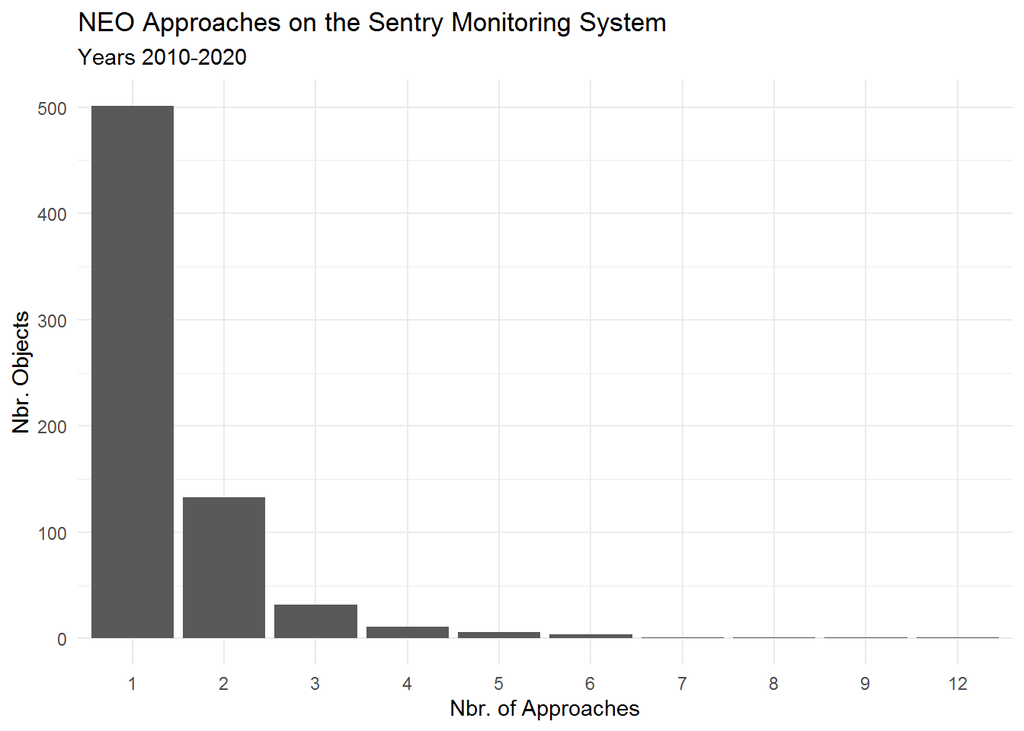

```r
collision_NEO_2010 <- collision_NEO %>% filter(decade == "2010")

collision_NEO_2010_grp <- collision_NEO_2010 %>% group_by(Object) %>%
  summarise(objects = n_distinct(`Close-Approach_Date`))

ggplot(collision_NEO_2010_grp) + geom_histogram(aes(x = factor(collision_NEO_2010_grp$objects)), stat = "count") +
  labs(title = "NEO Approaches on the Sentry Monitoring System",
       subtitle = "Years 2010-2020",
       x = "Nbr. of Approaches",
       y = "Nbr. Objects") +
  theme_minimal()
```

Most objects in the last decade, it seems, passed by only once.

### 4.3.1 2010-2020 NEO Sentry Data by Year

What does the by year breakdown look like for this period?

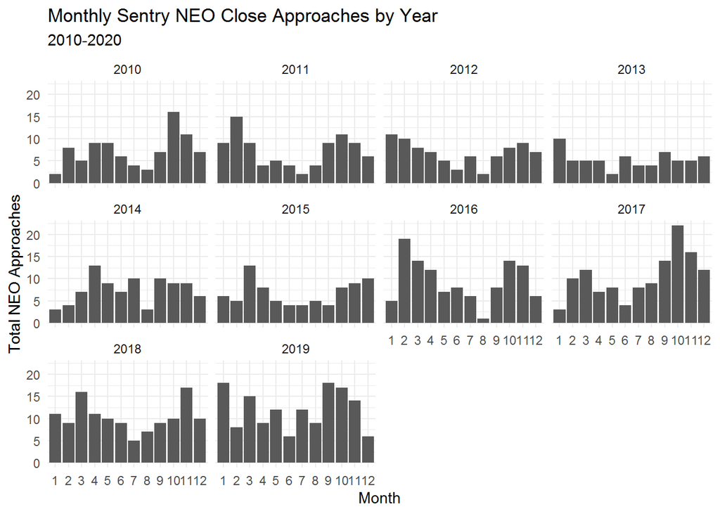

```r
ggplot(collision_NEO_2010) +
         geom_bar(aes(x = factor(month(ymd(collision_NEO_2010$`Close-Approach_Date`))))) +
         facet_wrap(~year(ymd(collision_NEO_2010$`Close-Approach_Date`))) +
      theme_minimal() +
  #theme(axis.text.x = element_blank()) +
  labs(title = "Monthly Sentry NEO Close Approaches by Year",
       subtitle = "2010-2020",
       x = "Month",
       y = "Total NEO Approaches")
```

Visually, we can see see a bit of a trend here. It appears colder months have more NEO approaches than warmer ones except 2013.

### 4.3.2 What would an all-time month by month breakdown look like?

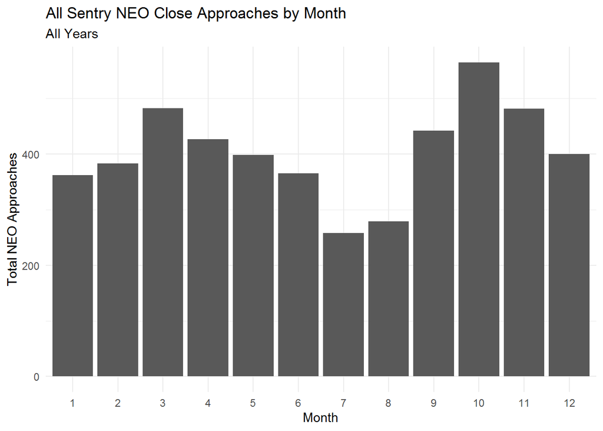

```r
ggplot(collision_NEO) +
         geom_bar(aes(x = factor(month(ymd(collision_NEO$`Close-Approach_Date`))))) +
         #facet_wrap(~year(ymd(collision_NEO_2010$`Close-Approach_Date`))) +
      theme_minimal() +
  #theme(axis.text.x = element_blank()) +
  labs(title = "All Sentry NEO Close Approaches by Month",
       subtitle = "All Years",
       x = "Month",
       y = "Total NEO Approaches")
```

That appears to be the general trend throughout all of the data.

A box plot of the 2010-2020 decade shows it off nicely.

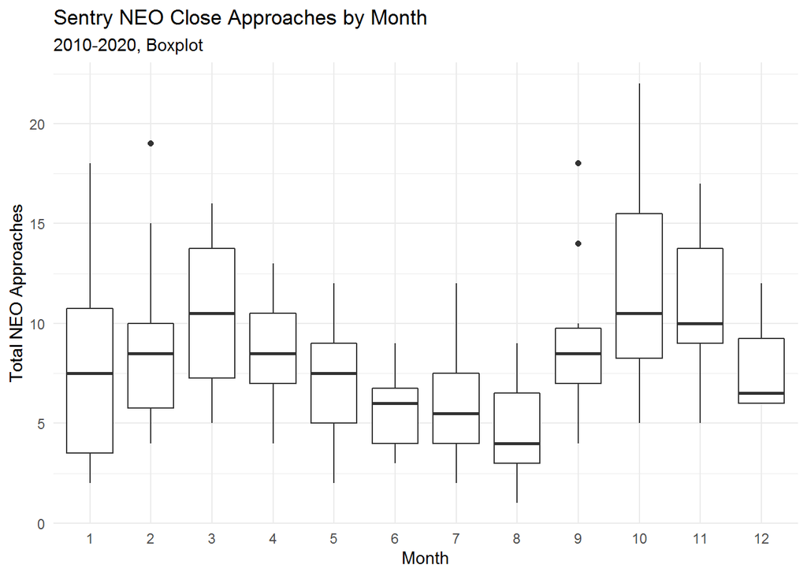

```r
collision_NEO_2010_month_count <- collision_NEO_2010 %>%
  count(month(ymd(collision_NEO_2010$`Close-Approach_Date`)), year(ymd(collision_NEO_2010$`Close-Approach_Date`)))
colnames(collision_NEO_2010_month_count) <- c("Month", "Year", "n")


ggplot(collision_NEO_2010_month_count, aes(x = factor(Month), y = n)) +
         geom_boxplot() +
         theme_minimal() +
   labs(title = "Sentry NEO Close Approaches by Month",
       subtitle = "2010-2020, Boxplot",
       x = "Month",
       y = "Total NEO Approaches")
```

It would seem that October is the most active month for Sentry Monitored NEO Close Approaches.

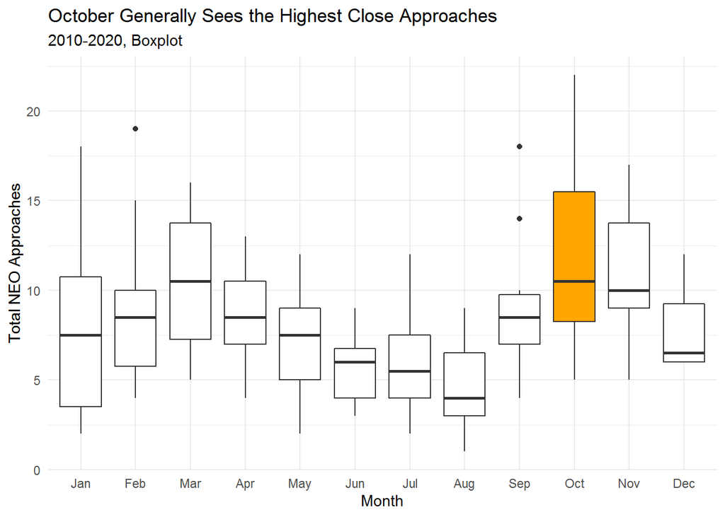

```r
collision_NEO_2010_month_count$Month  <- factor(collision_NEO_2010_month_count$Month)

levels(collision_NEO_2010_month_count$Month) <- c("Jan", "Feb", "Mar", "Apr", "May", "Jun", "Jul", "Aug", "Sep", "Oct", "Nov", "Dec")

ggplot(collision_NEO_2010_month_count, aes(x = factor(Month), y = n)) +
         geom_boxplot(fill = c("white","white","white","white","white","white","white","white","white","orange","white","white")) +
         theme_minimal() +
   labs(title = "October Generally Sees the Highest Close Approaches",
       subtitle = "2010-2020, Boxplot",
       x = "Month",
       y = "Total NEO Approaches")
```

And once more with points per year.

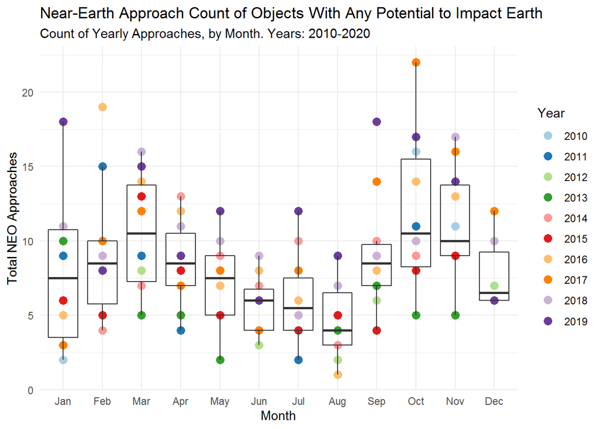

```r
library(RColorBrewer)

ggplot(collision_NEO_2010_month_count, aes(x = Month, y = n)) +
  geom_point(size = 3, alpha = 1, aes(color = factor(collision_NEO_2010_month_count$Year))) +
  scale_color_brewer(type = "qual", palette = "Paired") +
  geom_boxplot(alpha = 0) +
  theme_minimal() +
  labs(title = "Near-Earth Approach Count of Objects With Any Potential to Impact Earth",
       subtitle = "Count of Yearly Approaches, by Month. Years: 2010-2020",
       x = "Month",
       y = "Total NEO Approaches",
       color = "Year")
```

## 4.4 How fast are they going?

Can we get a sense of the speed of the objects?

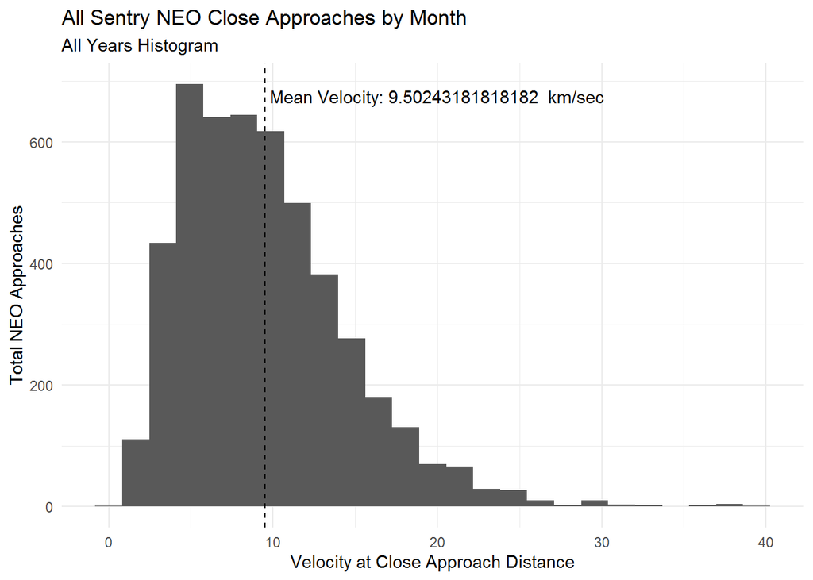

```r
ggplot(collision_NEO, aes(x = V_Relative)) +
         geom_histogram(bins = 25) +
         geom_vline(aes(xintercept=mean(collision_NEO$V_Relative)),linetype="dashed") +
         annotate("text", x = 20, y = 675, label = paste("Mean Velocity:", mean(collision_NEO$V_Relative), " km/sec"), color = "black") +
         theme_minimal() +
   labs(title = "All Sentry NEO Close Approaches by Month",
       subtitle = "All Years Histogram",
       x = "Velocity at Close Approach Distance",
       y = "Total NEO Approaches")
```

Does the shape of this histogram appear similar to our 2010 decade subset?

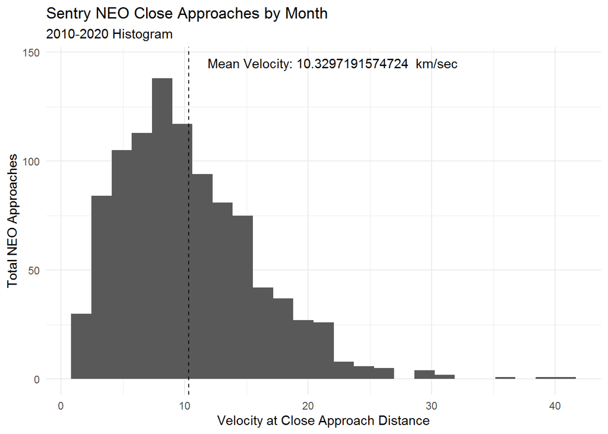

```r
ggplot(collision_NEO_2010, aes(x = V_Relative)) +
         geom_histogram(bins = 25) +
         geom_vline(aes(xintercept=mean(collision_NEO_2010$V_Relative)),linetype="dashed") +
         annotate("text", x = 22, y = 145, label = paste("Mean Velocity:", mean(collision_NEO_2010$V_Relative), " km/sec"), color = "black") +
         theme_minimal() +
   labs(title = "Sentry NEO Close Approaches by Month",
       subtitle = "2010-2020 Histogram",
       x = "Velocity at Close Approach Distance",
       y = "Total NEO Approaches")
```

We can overlay all this information, along with the true standard normal curves for each distribution to see even clearer that the trend continues within the entire population.

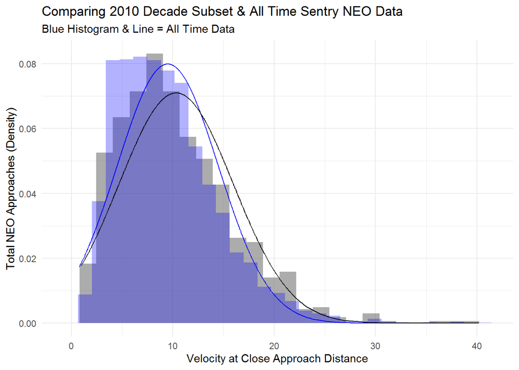

```r
# generate curves
v_2010_norm <- dnorm(collision_NEO_2010$V_Relative, mean(collision_NEO_2010$V_Relative), sd(collision_NEO_2010$V_Relative))
v_all_norm <- dnorm(collision_NEO$V_Relative, mean(collision_NEO$V_Relative), sd(collision_NEO$V_Relative))
# plot
ggplot(collision_NEO_2010, aes(x = V_Relative, y = ..density..)) +
  geom_histogram(bins = 25, alpha = .5) +
  geom_histogram(data = collision_NEO, aes(x = collision_NEO$V_Relative, y = ..density..), fill = "blue", alpha = .3) +
  geom_line(data = collision_NEO, aes(x = collision_NEO$V_Relative, y = v_all_norm), color = "blue") +
  geom_line(data = collision_NEO_2010, aes(x = collision_NEO_2010$V_Relative, y = v_2010_norm)) +
  #geom_vline(aes(xintercept=mean(collision_NEO_2010$V_Relative)),linetype="dashed") +
  #annotate("text", x = 22, y = 145, label = paste("Mean Velocity:", mean(collision_NEO_2010$V_Relative), " km/sec"), color = "black") +
  theme_minimal() +
  labs(title = "Comparing 2010 Decade Subset & All Time Sentry NEO Data",
       subtitle = "Blue Histogram & Line = All Time Data",
       x = "Velocity at Close Approach Distance",
       y = "Total NEO Approaches (Density)")
```

One further question I wonder is if there is any apparent trend to the speed of NEOs and the month they have their close approach?

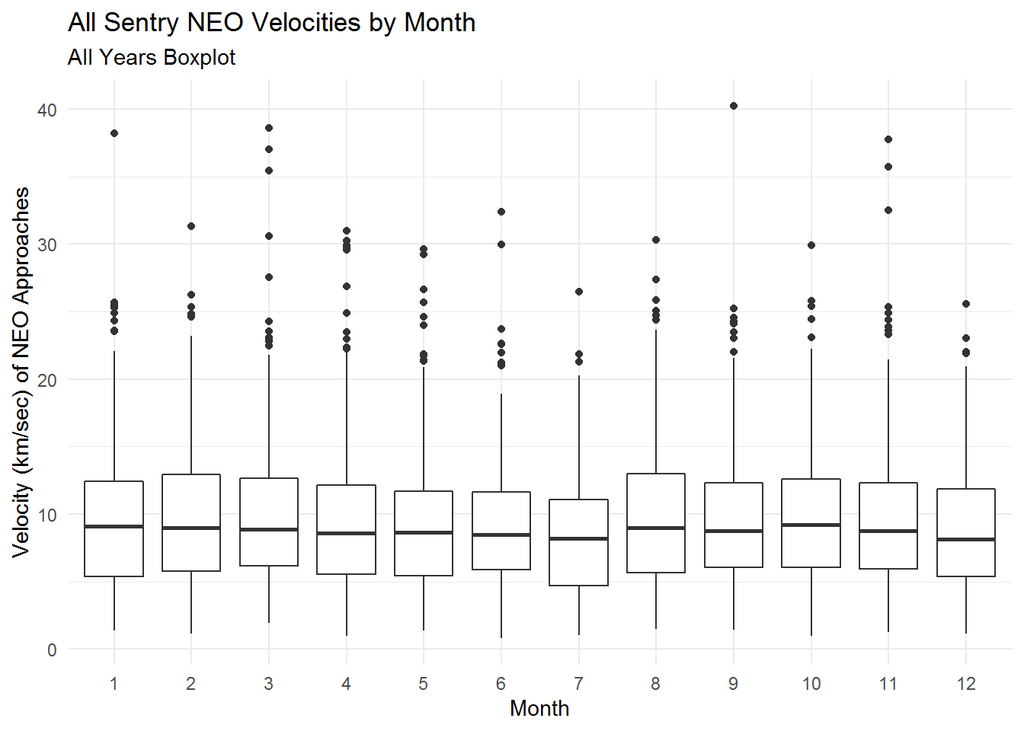

```r
ggplot(collision_NEO, aes(x = factor(month(ymd(collision_NEO$`Close-Approach_Date`))), y = V_Relative)) +
  geom_boxplot() +
  theme_minimal() +
  labs(title = "All Sentry NEO Velocities by Month",
       subtitle = "All Years Boxplot",
       x = "Month",
       y = "Velocity (km/sec) of NEO Approaches")
```

Even a quick glance at this box plot shows that speed has no reasonably impact on what month it may approach.

## 4.5 But wait…how big are these things?

Let’s take a look. We’ll start by seeing if a histogram gives us a good idea of the size of these objects. For now, we will still be counting on *approaches*, which may skew the count totals.

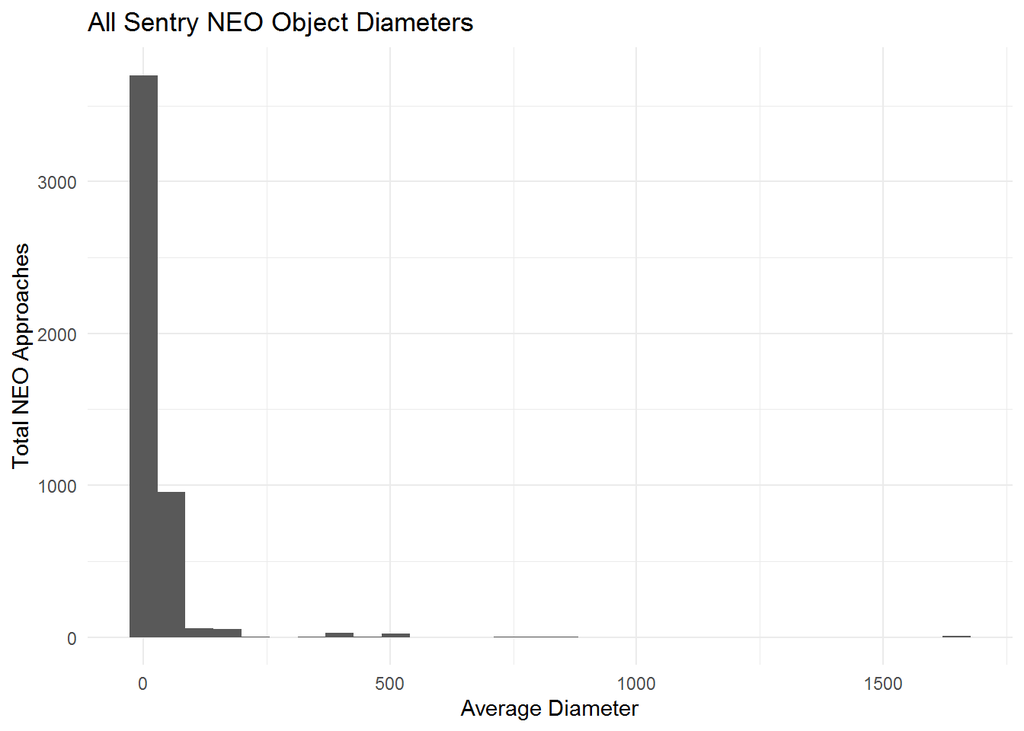

```r
ggplot(collision_NEO, aes(x = collision_NEO$avg_diameter)) +
  geom_histogram() +
  theme_minimal() +
  labs(title = "All Sentry NEO Object Diameters",
       x = "Average Diameter",
       y = "Total NEO Approaches")
```

An enormous outlier is making this histogram difficult to read. We can try limiting the x-axis

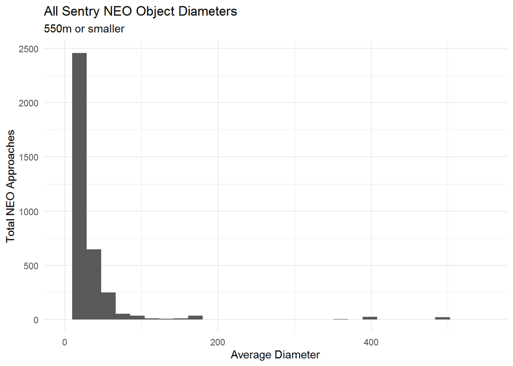

```r
ggplot(collision_NEO, aes(x = collision_NEO$avg_diameter)) +
  geom_histogram() +
  theme_minimal() +
  labs(title = "All Sentry NEO Object Diameters",
       subtitle = "550m or smaller",
       x = "Average Diameter",
       y = "Total NEO Approaches") +
  xlim(0,550)
```

This is better, but still we have outliers sitting more than double in size away from the main bins.

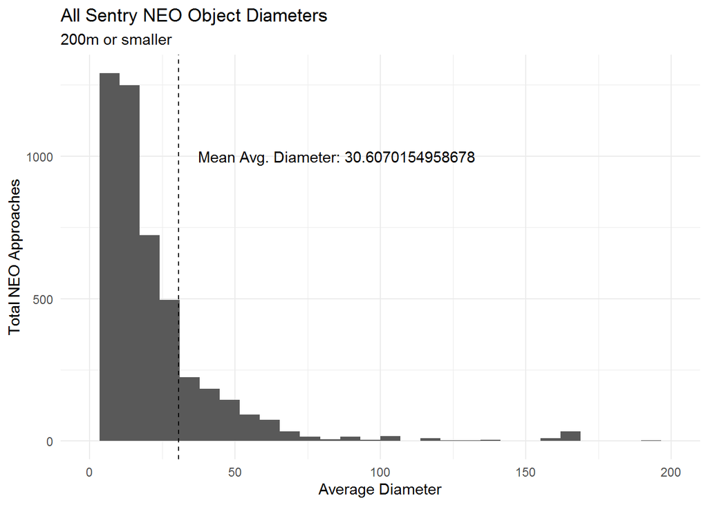

```r
ggplot(collision_NEO, aes(x = collision_NEO$avg_diameter)) +
  geom_histogram() +
  geom_vline(aes(xintercept=mean(collision_NEO$avg_diameter)),linetype="dashed") +
  annotate("text", x = 85, y = 1000, label = paste("Mean Avg. Diameter:", mean(collision_NEO$avg_diameter)), color = "black") +
  theme_minimal() +
  labs(title = "All Sentry NEO Object Diameters",
       subtitle = "200m or smaller",
       x = "Average Diameter",
       y = "Total NEO Approaches") +
  xlim(0,200)
```

This is better, and gives a good look at how the objects are very positively skewed. Most, it seems, are (relatively) small.

## 4.6 Is there any correlation to the size of an object and its speed?

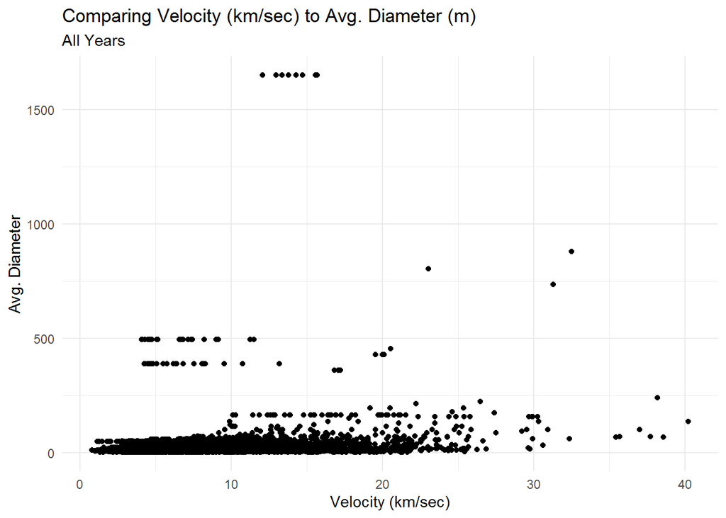

```r
ggplot(collision_NEO, aes(x = V_Relative, y = avg_diameter)) +
  geom_point() +
  theme_minimal() +
  labs(title = "Comparing Velocity (km/sec) to Avg. Diameter (m)",
       subtitle = "All Years",
       x = "Velocity (km/sec)",
       y = "Avg. Diameter")
```

Right off the bat this feels highly uncorrelated. Let’s run it through the cor() function.

```r
cor(collision_NEO$avg_diameter, collision_NEO$V_Relative)
```

```
## [1] 0.130391
```

This doesn’t feel worth following.

## 4.7 But is there a correlation somewhere here we can follow?

```r
all_cor <- cor(collision_NEO[, c("V_Relative", "avg_diameter", "Potential_Impacts", "Palermo_Scale_max", "decade")], use = "complete")
print(all_cor)
```

```
##                    V_Relative avg_diameter Potential_Impacts
## V_Relative         1.00000000  0.130390998      -0.051907239
## avg_diameter       0.13039100  1.000000000      -0.001330675
## Potential_Impacts -0.05190724 -0.001330675       1.000000000
## Palermo_Scale_max  0.03266967  0.329192026       0.230488087
## decade             0.08791010  0.031273725      -0.031279498
##                   Palermo_Scale_max      decade
## V_Relative               0.03266967  0.08791010
## avg_diameter             0.32919203  0.03127372
## Potential_Impacts        0.23048809 -0.03127950
## Palermo_Scale_max        1.00000000 -0.02574939
## decade                  -0.02574939  1.00000000
```

The three categories that approach something even slightly above a negligible correlation are Palermo Scale Max, Average Diameter, and Potential Impacts.

Let’s scatter plot matrix these and get a look.

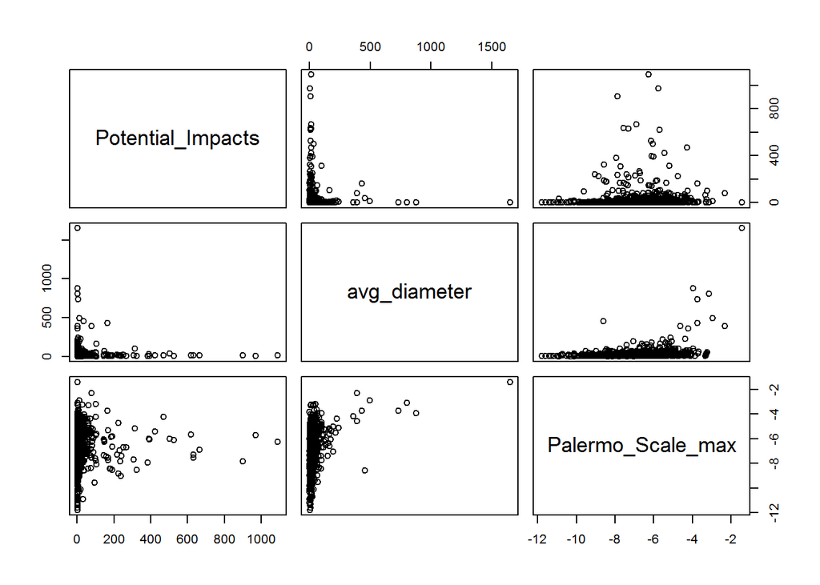

```r
pairs(data = collision_NEO, ~Potential_Impacts + avg_diameter + Palermo_Scale_max)
```

Now, we’ll dig a touch more into Palermo Scale Max and Average Diameter.

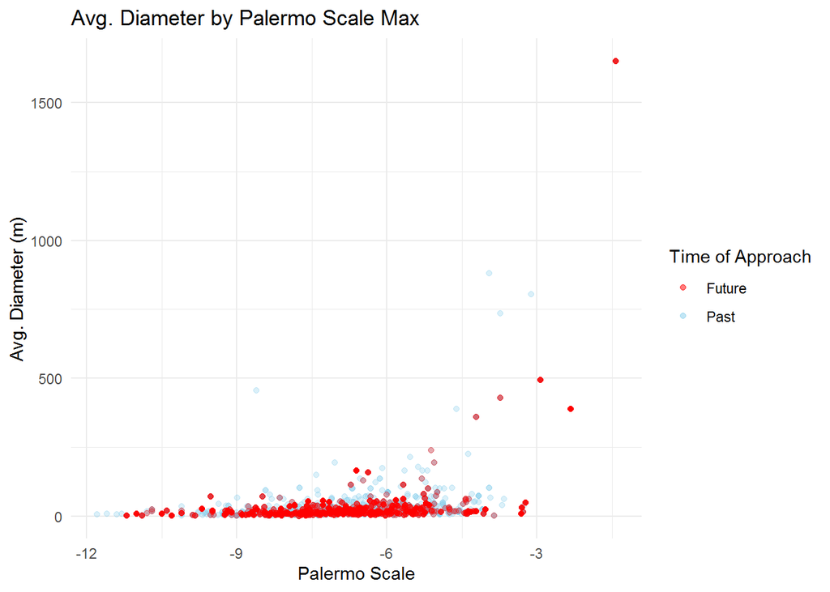

```r
future_neo <- collision_NEO[year(ymd(collision_NEO$`Close-Approach_Date`)) > 2019,]

ggplot(collision_NEO, aes(x = collision_NEO$Palermo_Scale_max, y = collision_NEO$avg_diameter, color = "skyblue")) +
  geom_point(alpha = .3) +
  geom_point(data = future_neo, aes(x = future_neo$Palermo_Scale_max, y = future_neo$avg_diameter, colour = "red"), alpha = .3) +
  labs(title = "Avg. Diameter by Palermo Scale Max",
       x = "Palermo Scale",
       y = "Avg. Diameter (m)") +
    theme_minimal() +
   scale_color_identity(name = "Time of Approach",
                          breaks = c("red", "skyblue"),
                          labels = c("Future", "Past"),
                          guide = "legend")
```

While it’s true that the correlation here is weak, it’s also true that the number of smaller objects vastly outweighs the larger ones. Would this correlation be strongler if the numbers weren’t so skewed? We can see that aside from only one point, nearly all objects at, around or above 500m in diameter are inching closer to the the -2 cutoff for Polermo Scale. Of the entire dataset, only 1 crosses that barrier.

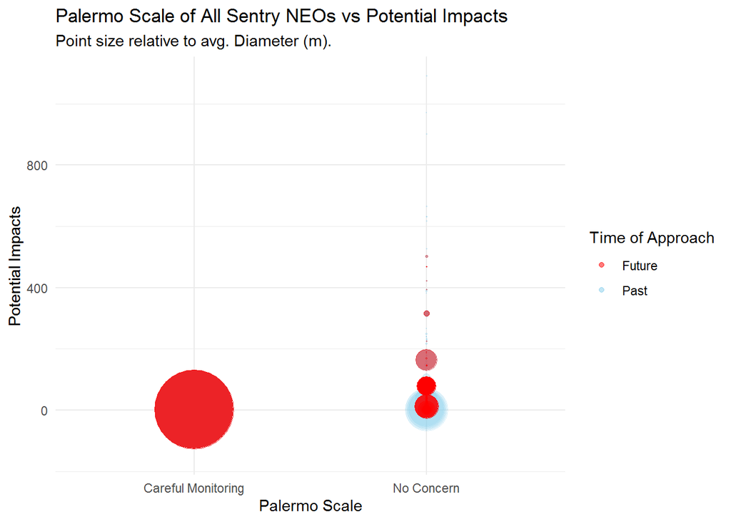

```r
ggplot(collision_NEO, aes(x = factor(collision_NEO$pscale), y = collision_NEO$Potential_Impacts, color = "skyblue")) +
  geom_point(size = collision_NEO$avg_diameter/65, alpha = .3) +
  geom_point(data = future_neo, aes(x = factor(future_neo$pscale), y = future_neo$Potential_Impacts,  colour = "red"), size = future_neo$avg_diameter/65, alpha = .3) +
  labs(title = "Palermo Scale of All Sentry NEOs vs Potential Impacts",
       subtitle = "Point size relative to avg. Diameter (m).",
       x = "Palermo Scale",
       y = "Potential Impacts") +
  theme_minimal() +
  ylim(-150, max(collision_NEO$Potential_Impacts)) +
  scale_color_identity(name = "Time of Approach",
                          breaks = c("red", "skyblue"),
                          labels = c("Future", "Past"),
                          guide = "legend")
```

This gives us a nice idea of how concerning a threat is, how many times it may pose a threat, and how big that threat might be: Which, considering only one object is in the **Careful** Monitoring category of the Palermo Scale, isn’t much at all. Visually, though, this lacks the true representation of how often these approaches have, and will occur. Let’s jitter the points and limit the y-axis a touch to get a better idea.

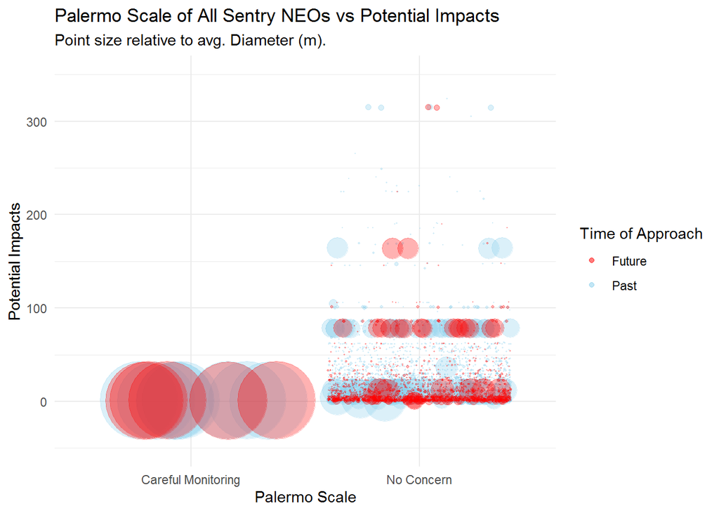

```r
ggplot(collision_NEO, aes(x = factor(collision_NEO$pscale), y = collision_NEO$Potential_Impacts, color = "skyblue")) +
  geom_point(position = "jitter", size = collision_NEO$avg_diameter/65, alpha = .3) +
  geom_point(position = "jitter", data = future_neo, aes(x = factor(future_neo$pscale), y = future_neo$Potential_Impacts, colour = "red"), size = future_neo$avg_diameter/65, alpha = .3) +
  #geom_point(aes(x = factor(collision_NEO$pscale)[104], y = 200), size = 3, vjust = 100) +
  labs(title = "Palermo Scale of All Sentry NEOs vs Potential Impacts",
       subtitle = "Point size relative to avg. Diameter (m).",
       x = "Palermo Scale",
       y = "Potential Impacts") +
  theme_minimal() +
   #scale_colour_manual(name = 'the colour',
        # values =c('black'='black','red'='red'), labels = c('c2','c1')) +
  ylim(-50, 350) +
  scale_color_identity(name = "Time of Approach",
                          breaks = c("red", "skyblue"),
                          labels = c("Future", "Past"),
                          guide = "legend")
```

## 4.8 Lunar Distance

One measurement we haven’t looked at yet is Lunar Distance. 1 LD = the distance between the Earth and the Moon. This information is included in the dataset, but it’s combined with AU (distance between Earth and the Sun), so we’ll need to split it out, similar to what we did with Avg. Diameter, and add them to their own column.

```r
collision_NEO$lunar_distance <- as.numeric(substr(collision_NEO$CA_Distance_Nominal,1,5))
```

I’d like to do a quick correlation analysis with these numbers now.

```r
all_cor <- cor(collision_NEO[, c("V_Relative", "avg_diameter", "Potential_Impacts", "Palermo_Scale_max", "decade", "lunar_distance")], use = "complete")
print(all_cor)
```

```
##                    V_Relative avg_diameter Potential_Impacts
## V_Relative         1.00000000  0.130390998      -0.051907239
## avg_diameter       0.13039100  1.000000000      -0.001330675
## Potential_Impacts -0.05190724 -0.001330675       1.000000000
## Palermo_Scale_max  0.03266967  0.329192026       0.230488087
## decade             0.08791010  0.031273725      -0.031279498
## lunar_distance     0.04184463  0.006873830      -0.069664673
##                   Palermo_Scale_max      decade lunar_distance
## V_Relative              0.032669667  0.08791010    0.041844629
## avg_diameter            0.329192026  0.03127372    0.006873830
## Potential_Impacts       0.230488087 -0.03127950   -0.069664673
## Palermo_Scale_max       1.000000000 -0.02574939    0.007982741
## decade                 -0.025749386  1.00000000    0.014088120
## lunar_distance          0.007982741  0.01408812    1.000000000
```

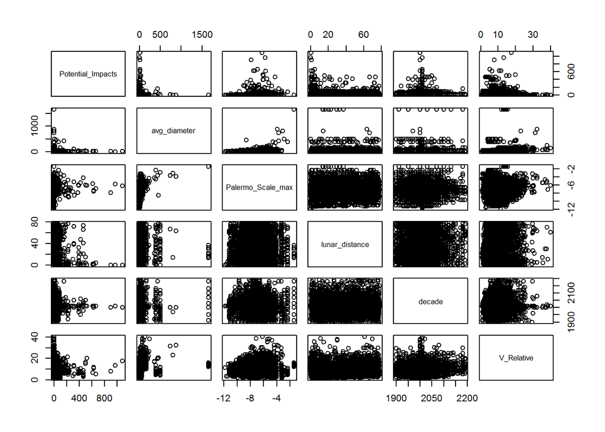

```r
pairs(data = collision_NEO, ~Potential_Impacts + avg_diameter + Palermo_Scale_max + lunar_distance + decade + V_Relative)
```

Lunar Distance appears to have no correlation at all to the other measurements, which surprises me, but there it is.

### 4.8.1 Distribution of Lunar Distances.

[figure not shown]

```r
ggplot(collision_NEO, aes(x = as.numeric(collision_NEO$lunar_distance))) +
  geom_histogram(bins = 35) +
  geom_vline(aes(xintercept=mean(as.numeric(collision_NEO$lunar_distance))),linetype="dashed") +
  annotate("text", x = 55, y = 400, label = paste("Mean Lunar Distance:", mean(collision_NEO$avg_diameter)), color = "black") +
  theme_minimal() +
  labs(title = "All Sentry NEO Object Lunar Distances",
       x = "Lunar Distance",
       y = "Total NEO Approaches")
```

This is an interesting distribution. Many more close approaches occur at or below 3 Lunar Distances, and then the number of approaches beyond that stay relatively even. Lunar distance appears to be somewhat uniform, and uncorrelated with any other measurements.

# 5 Conclusion

While we were able to scrape together a minor correlation at the end, the only repeatable pattern to be found was the October spike of NEO Approaches. This could be worthy of a further reading, though I theorize (with limited evidence, for now) it must have something about the angle of the Earth at that time of year.

I believe this particular avenue of the dataset could be an entire analysis document of its own.